# Question

A turtle starts at the star in the middle. By dragging markers along a grid, she makes 5 line segments. The first segment is red, and then she changes color after each turn, following the progression of a rainbow.

The distance between adjacent dots is 1 unit. The grid is oriented with North pointing up and East pointing right.

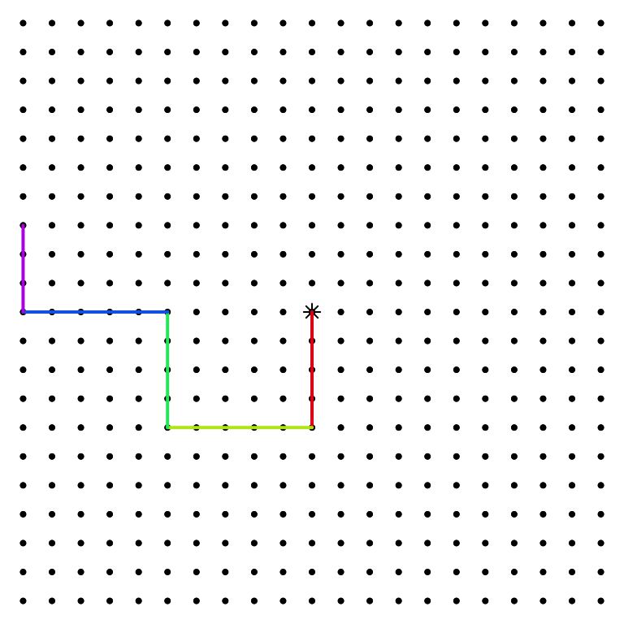

Describe the path taken by the turtle.

## Answerlist

- North
- East
- South
- West
- 1
- 2
- 3
- 4
- 5
- North
- East
- South
- West
- 1
- 2
- 3
- 4
- 5
- North
- East
- South
- West
- 1
- 2
- 3
- 4
- 5
- North
- East
- South
- West
- 1
- 2
- 3
- 4
- 5
- North
- East
- South
- West
- 1
- 2
- 3
- 4
- 5

# Solution

- South 4
- West 5
- North 4
- West 5
- North 3

# Meta-information

extype: cloze exclozetype: schoice|schoice|schoice|schoice|schoice|schoice|schoice|schoice|schoice|schoice exsolution: 0010|00010|0001|00001|1000|00010|0001|00001|1000|00100 exname: turtle_path_01